# ATOM-USD

## ATOM-USD today is +0200, 2025-10-28, 12:27:09

This crypto forecast was generated by gemini-2.0-flash API

## Daily Chart

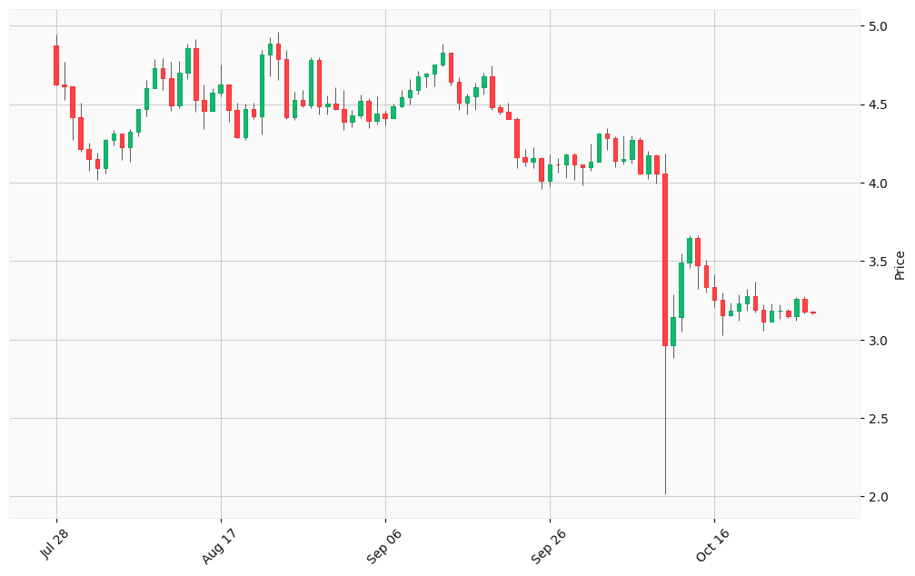

## Hourly Chart

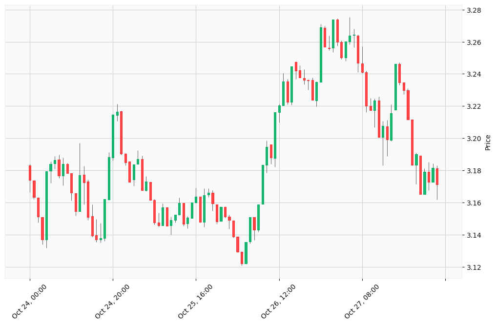

Okay, I will analyze the provided ATOM-USD cryptocurrency data, incorporating technical analysis, trend analysis, news/economic factors, and scenario evaluation to generate buy and sell signals. I will use moving averages, RSI, MACD and other indicators on the data you provided.

Here’s an analysis of ATOM-USD, generating potential trading signals:

### **Market Data Collection**

- **Price:** As of October 26, 2025, ATOM is around $3.18-$3.26.
- **Market Cap:** Approximately $1.5 Billion.
- **Recent News:**
  - A market crash on October 10, 2025, saw ATOM drop significantly.
  - Mixed sentiment exists with technical traders eyeing potential breakouts, while fundamental analysts are cautious due to inflation.
  - Real Finance launched a Cosmos-based tokenization platform for real-world assets.